# PSTAT131 Final Project

2022/5/25

## Introduction

As a modern electronic payment method, credit card is usually issued by commercial banks or other financial institutions. Its main uses include: consumer payment, credit loan, transfer settlement, etc. At the current stage, the large-scale use of credit cards has brought great changes to the financial industry, but it has also created some risks. Due to the endless emergence of financial fraud methods and related negative news, how to do a good job of risk control in the Internet financial industry is also a big problem.  
Therefore, it is very important to establish an effective model to help credit card companies identify fraudulent transactions, thereby reducing the proportion of fraud, reducing fraud losses, and promoting the healthy development of the credit card industry.

## Loading Data and Packages

The data for this project comes from the kaggle competition platform see https://www.kaggle.com/datasets/mlg-ulb/creditcardfraud, the dataset contains transactions made by credit cards in September 2013 by European cardholders. This dataset presents transactions that occurred in two days, where we have 492 frauds out of 284,807 transactions.  
It contains only numerical input variables which are the result of a PCA transformation. Unfortunately, due to confidentiality issues, kaggle cannot provide the original features and more background information about the data. Features V1, V2, … V28 are the principal components obtained with PCA , the only features which have not been transformed with PCA are ‘Time’ and ‘Amount’. Feature ‘Time’ contains the seconds elapsed between each transaction and the first transaction in the dataset. The feature ‘Amount’ is the transaction Amount, this feature can be used for example-dependant cost-sensitive learning. Feature ‘Class’ is the response variable and it takes value 1 in case of fraud and 0 otherwise.

```r
library(tidyverse)
library(tidymodels)
library(corrplot)
library(caret) #down
library(smotefamily)
library(janitor)
library(skimr)
library(patchwork)
library(lubridate)
library(ranger)
library(rlang)
library(dplyr)
#library(ggplot2)
#library(corrr)
library(klaR)
library(MASS) #upsample
#library(discrim)
library(poissonreg)
#library(stringr)
library(installr)
setwd('C:/Users/wilson/Desktop')
df <- read_csv("creditcard.csv")
head(df)
```

## Data Cleaning

. checking missing values We confirmed that none of the variables have missing values.

```r
colSums(is.na(df))
```

[output not shown]

.Clean names

```r
df %>%
  clean_names()
```

## Data Split

The dataset contains a total of 284807 samples,of which 80% of the data is used as training data about 227845 and 20% of the data is used as test data about 56962.  
Stratified sampling was used as the Class distribution was skewed. (See more on that in the EDA).The data split was conducted prior to the EDA as I did not want to know anything about my testing data set before I tested my model on those observations.

```r
set.seed(123)
#stratified split according to class
df_split <-df %>%
           initial_split(df,prop = 0.8, strata = "Class")
df_train <- training(df_split)
df_test <- testing(df_split)
dim(df_train)
dim(df_test)
df_train %>% count(Class)
df_test %>% count(Class)
```

## Exploratory Data Analysis

### checking class imbalance

By observing the proportion of fraudulent transactions and non-fraudulent transactions, we found that the data has a serious imbalance, 99.8% of transactions are non-fraudulent transactions, and the proportion of fraudulent transactions is only about 0.17%.

```r
df %>%
  count(Class) %>%
  mutate(prop = n/sum(n))

# class imbalance in percentage
df_train %>%
  count(Class) %>%
  mutate(prop = n/sum(n))
```

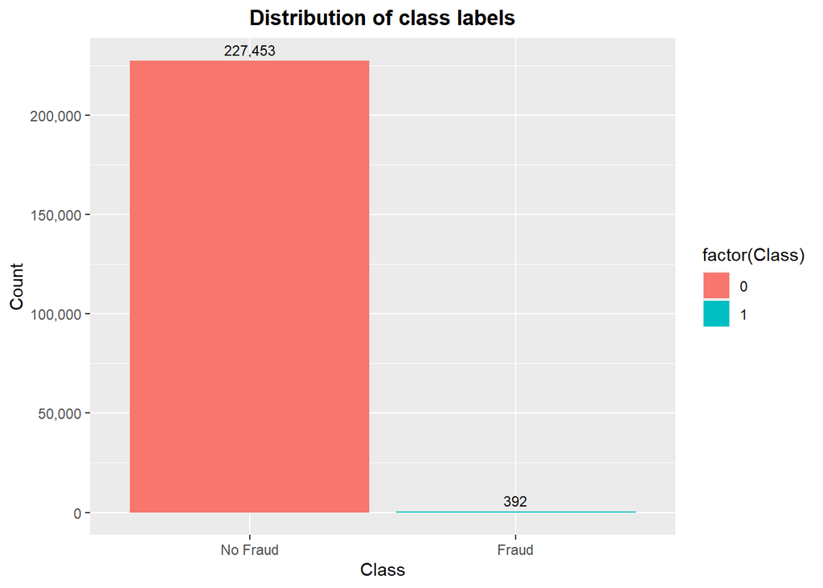

```r
common_theme <- theme(plot.title = element_text(hjust = 0.5, face = "bold"))

df_train %>%
ggplot(aes(x = factor(Class),
                            y = stat(count), fill = factor(Class),
                            label = scales::comma(stat(count)))) +
  geom_bar(position = "dodge") +
  geom_text(stat = 'count',
            position = position_dodge(.9),
            vjust = -0.5,
            size = 3) +
  scale_x_discrete(labels = c("No Fraud", "Fraud")) +
  scale_y_continuous(labels = scales::comma)+
  labs(x = 'Class', y = 'Count') +
  ggtitle("Distribution of class labels") +
  common_theme
```